# lab4

```python
# Lab 4 - Kun Lee, partner: Lexie Peterson
#Setup
%matplotlib inline
import numpy as np
import matplotlib
import matplotlib.pyplot as plt
import scipy
import scipy.signal
from scipy import stats

plt.rcParams["figure.figsize"] = (20,15)

d = stats.norm.rvs(loc = 5., scale = 0.01, size = 100000)
plt.rcParams["figure.figsize"] = (40,30)

import h5py
hf = h5py.File('gammaray_lab4.h5', 'r')
hf.keys()
```

```
<KeysViewHDF5 ['data']>
```

```python
data = np.array(hf.get('data'))
data[:,0]
hf.close()
```

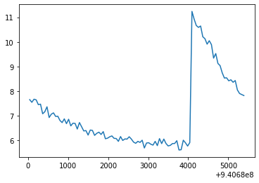

```python
time = data[0]
phase = data[1]
longitude = data[2]
count = data[3]
def binPlot(dataX, dataY, numBins, start, end):
    npDataX = np.array(dataX[start:end])
    npDataY = np.array(dataY[start:end])
    start = start
    location = start
    finish = end
    binDataX = np.empty(numBins)
    binDataY = np.empty(numBins)

    binsArrX = np.array_split(npDataX, numBins)
    binsArrY = np.array_split(npDataY, numBins)

    index = 0
    for arr in binsArrX:
        binDataX[index] = np.average(arr)
        index += 1

    index = 0
    for arr in binsArrY:
        binDataY[index] = np.average(arr)
        index += 1

    return [binDataX, binDataY]

fig, ax = plt.subplots(1,1)

one_orbit = (90*60*10)
bindata = binPlot(time, count, 100, 0, one_orbit)
ax.plot(bindata[0], bindata[1])
plt.show()
```

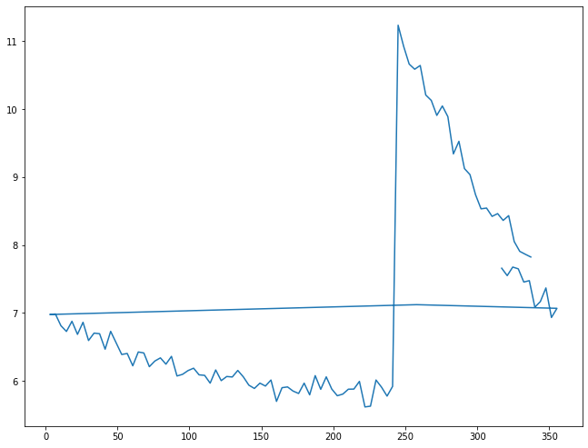

```python
bindata = binPlot(phase, count, 100, 0, one_orbit)

fig, ax = plt.subplots(1,1)
fig.set_size_inches(11,8.5)
ax.plot(bindata[0],bindata[1])
plt.show()
```

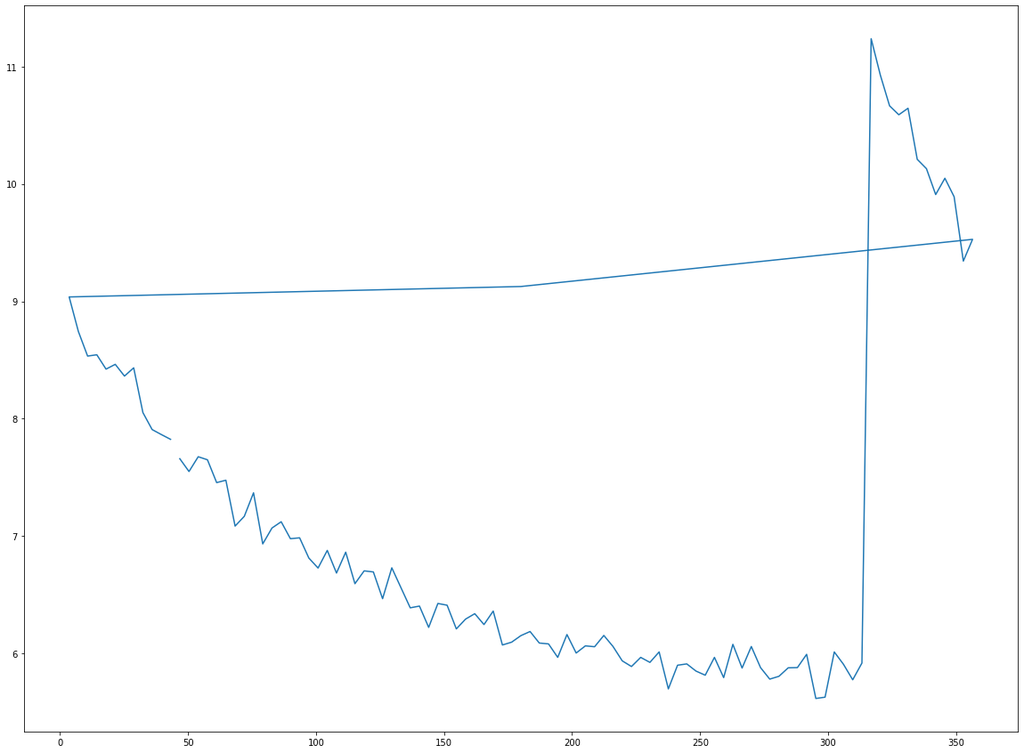

```python
bindata = binPlot(longitude, count, 100, 0, one_orbit)

fig, ax = plt.subplots(1,1)
ax.plot(bindata[0],bindata[1])
plt.show()
```

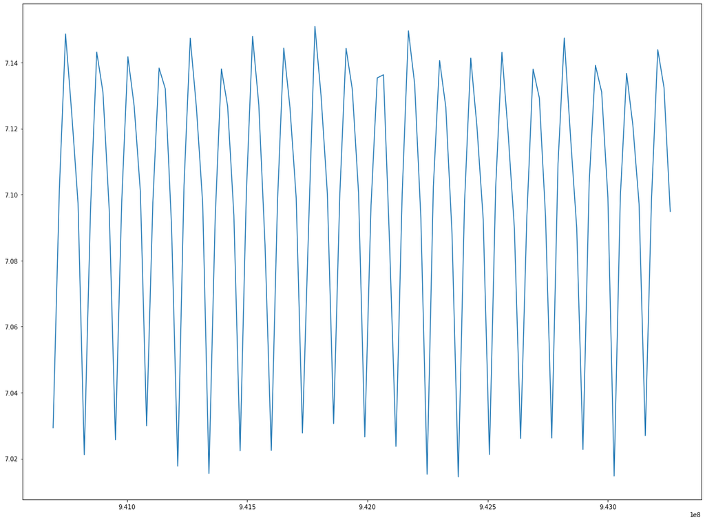

```python
bindata = binPlot(time, count, 100, 0, time.size)

fig, ax = plt.subplots(1,1)
ax.plot(bindata[0],bindata[1])
plt.show()
```

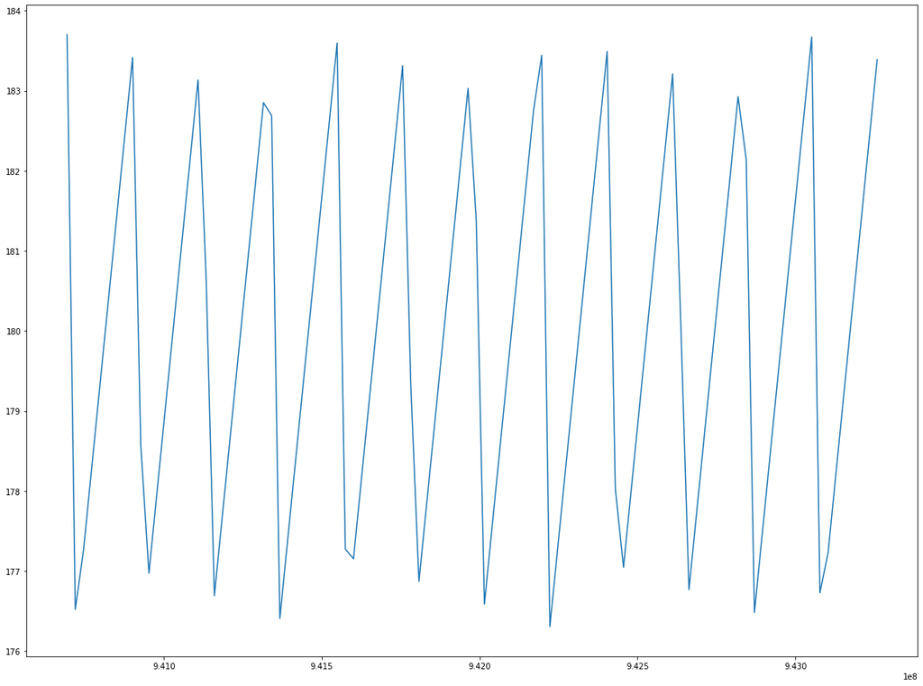

```python
bindata = binPlot(time, phase, 100, 0, time.size)

fig, ax = plt.subplots(1,1)
ax.plot(bindata[0],bindata[1])
plt.show()
```

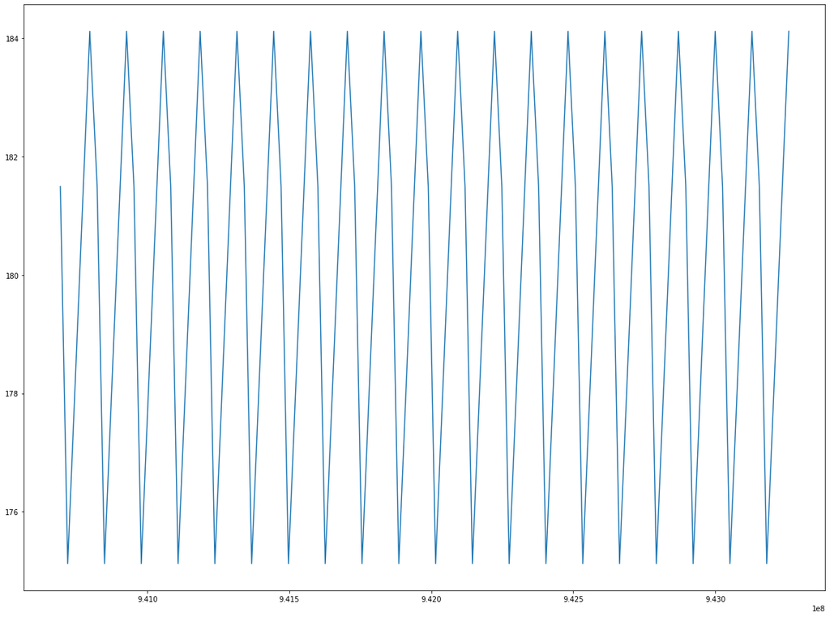

```python
bindata = binPlot(time, longitude, 100, 0, time.size)

fig, ax = plt.subplots(1,1)
ax.plot(bindata[0],bindata[1])
plt.show()
```

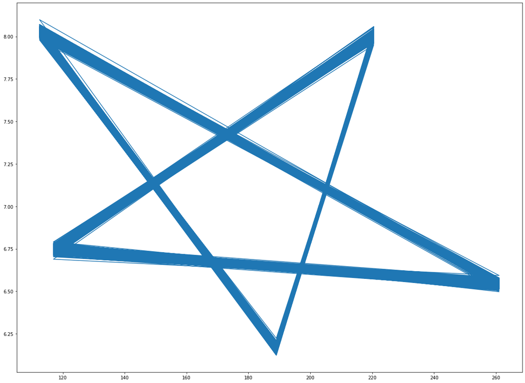

```python
bindata = binPlot(longitude, count, 1000, 0, one_orbit * 400)

fig, ax = plt.subplots(1,1)
ax.plot(bindata[0],bindata[1])
plt.show()
```

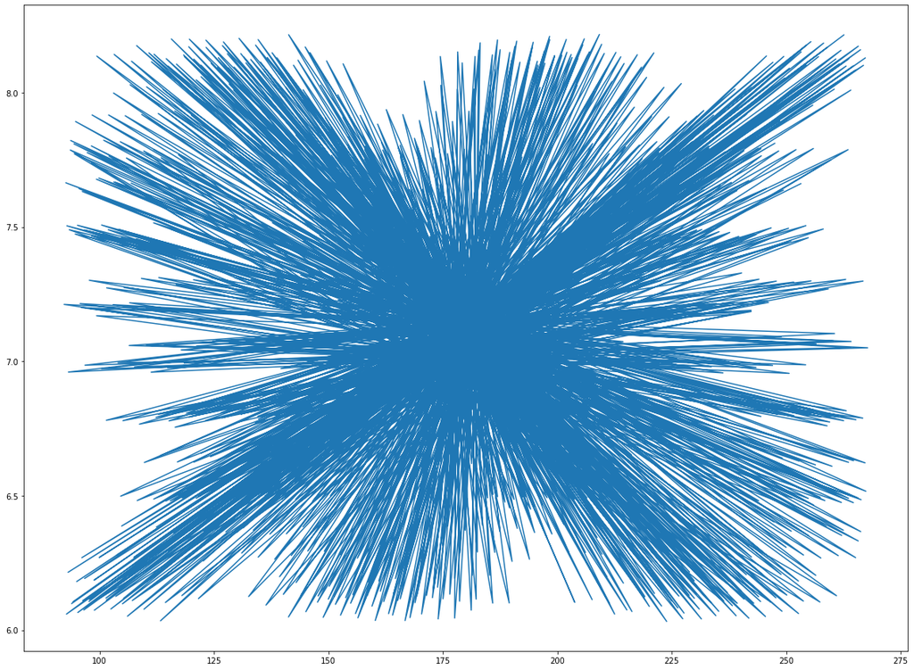

```python
bindata = binPlot(phase, count, 1000, 0, time.size)

fig, ax = plt.subplots(1,1)
ax.plot(bindata[0],bindata[1])
plt.show()
```

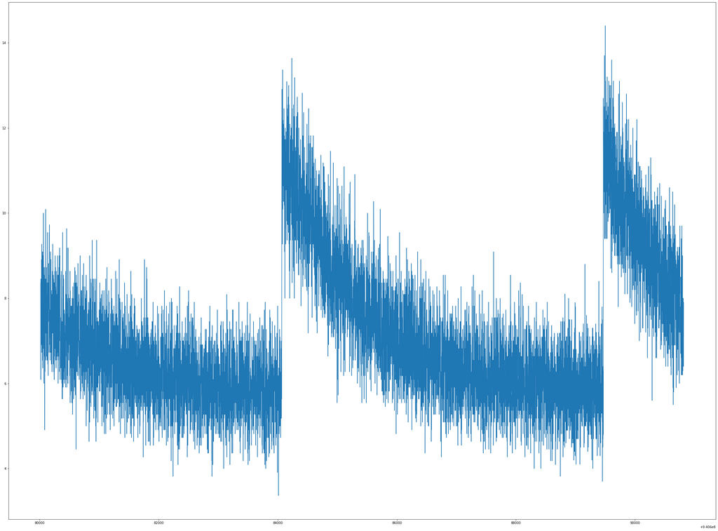

```python
bindata = binPlot(time, count, 10000, 0, one_orbit * 2)

fig, ax = plt.subplots(1,1)
ax.plot(bindata[0],bindata[1])
plt.show()
```

This looks periodic...

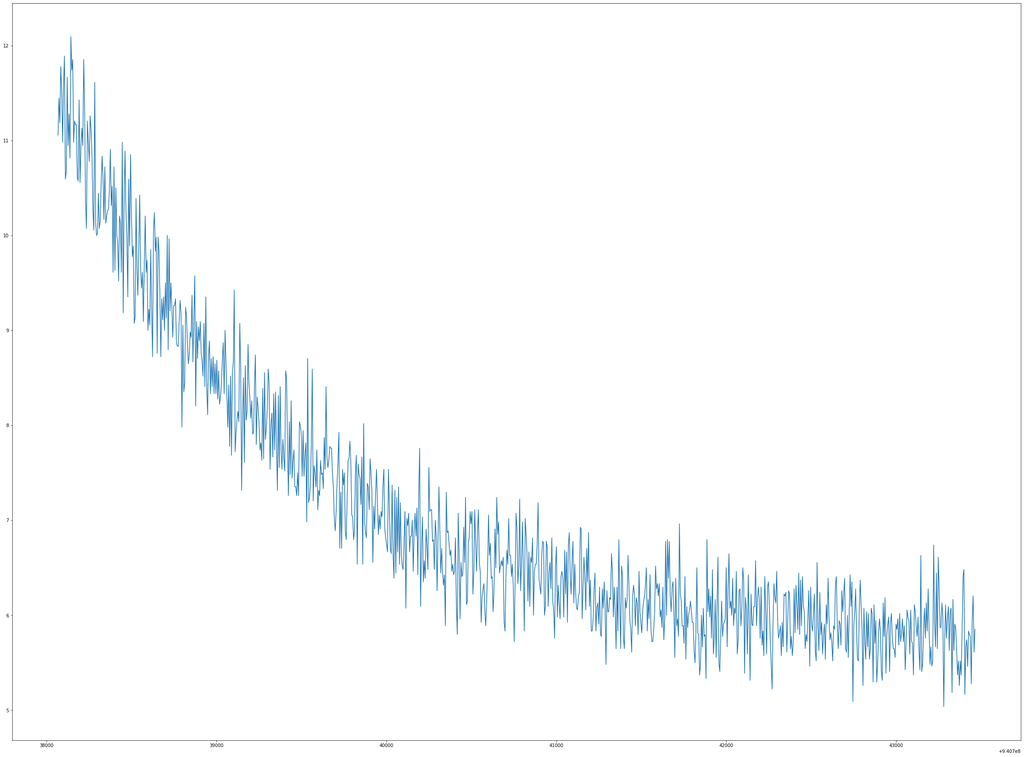

```
382
```

```python
bindata = binPlot(time, count, 1000, 40500 + (one_orbit * 10), 40500+(one_orbit * 11))

#y = scipy.argmin(count[0:one_orbit])
#z = scipy.argmax(count[0:one_orbit])
fig, ax = plt.subplots(1,1)
ax.plot(bindata[0],bindata[1])
#ax.plot(time[0:y:10],count[0:y:10])
plt.show()
y
```

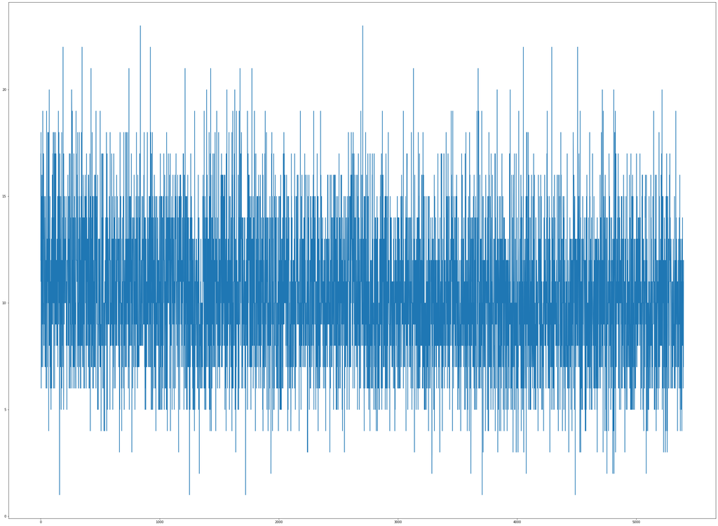

```python
((time.size - 40500) - 2701) / 5400
avg = np.zeros(5400)
for i in range(1):
    for j in range(5400):
        avg[j] = avg[j] + count[40500 + (i * 5400) + j]

for i in range(avg.size):
    avg[i] = avg[i] / 1

fig, ax = plt.subplots(1,1)
ax.plot(count[40500:(40500+5400)])
plt.show()
```

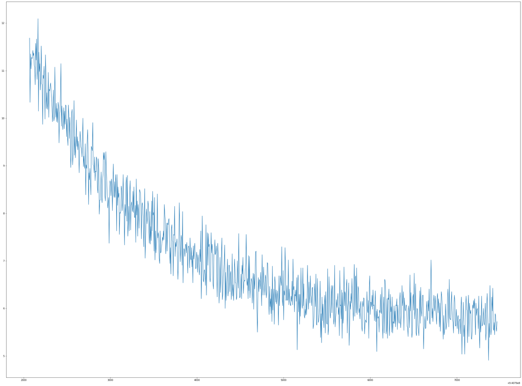

```
382
```

```python
bindata = binPlot(time, count, 1000, 40500 + (one_orbit * 20), 40500+(one_orbit * 21))

#y = scipy.argmin(count[0:one_orbit])
#z = scipy.argmax(count[0:one_orbit])
fig, ax = plt.subplots(1,1)
ax.plot(bindata[0],bindata[1])
#ax.plot(time[0:y:10],count[0:y:10])
plt.show()
y
```

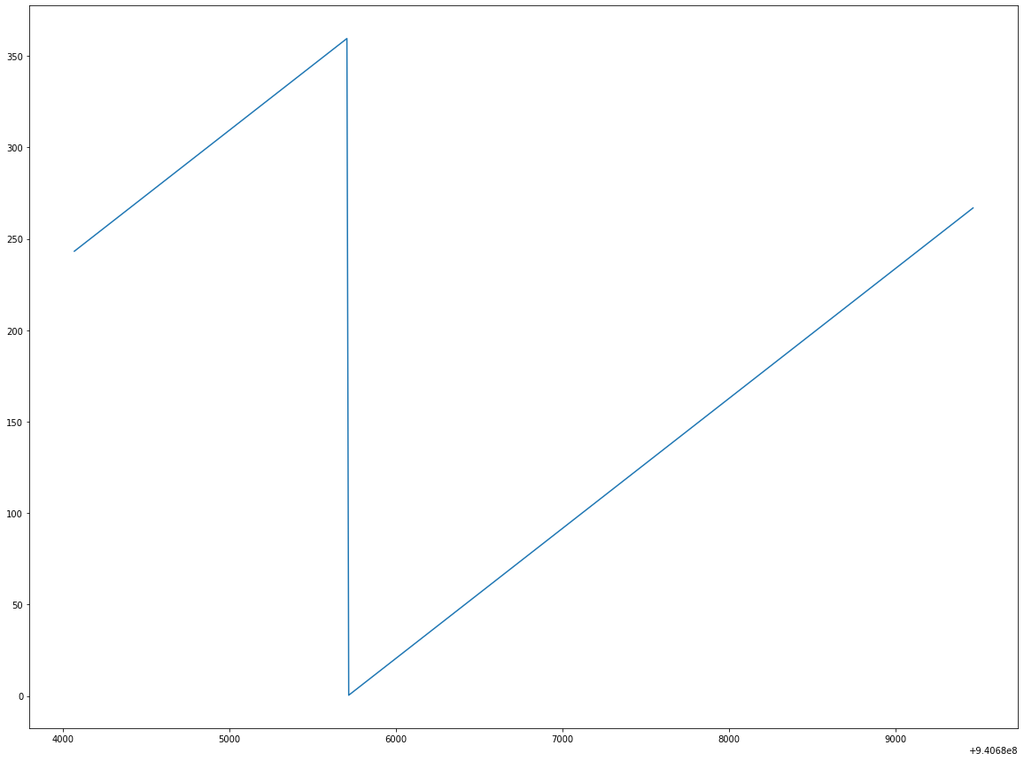

```python
bindata = binPlot(time, phase, 1000, 40500, 40500+(one_orbit))

fig, ax = plt.subplots(1,1)
ax.plot(bindata[0],bindata[1])
plt.show()
```

The phase is linear with respect to time.

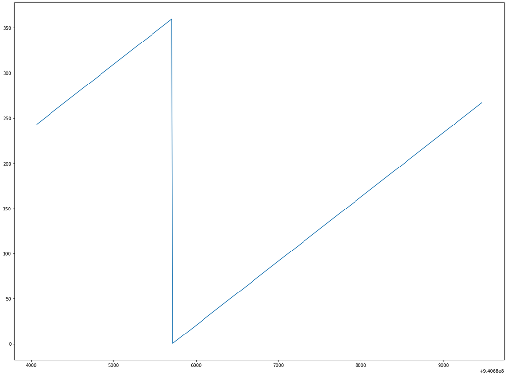

```python
bindata = binPlot(time, phase, 1000, 40500, 40500+(one_orbit))

fig, ax = plt.subplots(1,1)
ax.plot(bindata[0],bindata[1])
plt.show()
```

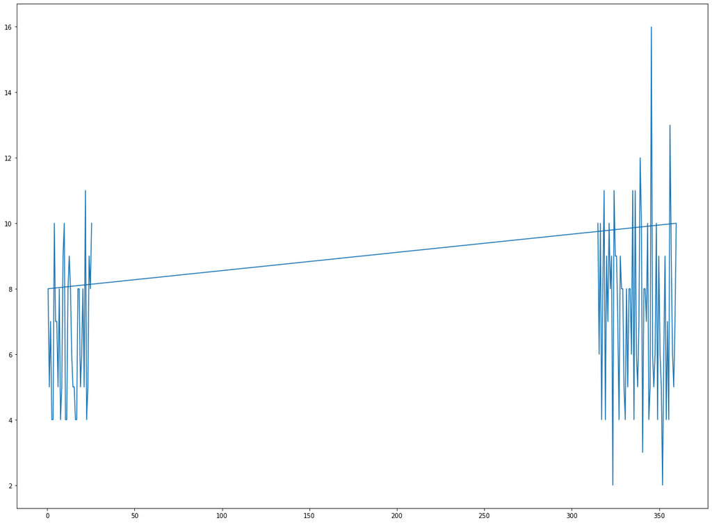

```python
bindata = binPlot(time, phase, 1000, 40500 + (one_orbit * 10), 40500+(one_orbit * 11))

fig, ax = plt.subplots(1,1)
ax.plot(phase[0:10000:100],count[0:10000:100])
plt.show()
```

It appears further plots are not going to reveal any more useful information. So, we conclude that the signal is periodic, but it changes in time across the dataset. I'm not exactly sure if there is signal contamination, but I doubt there is since the pattern forms an orderly, almost exponential looking curve with not a lot of deviation from the mean trendline.

3) Create a model for the background that includes time dependence, and explicitly compare your model to the data. How good is your model of the background? 4) Because the background varies, your discovery sensitivity threshold (how many particles you would need to see) also varies. What is the '5-sigma' threshold for a 100 millisecond GRB at different times?

Since the model is time dependent, my approach is to split the signal into different bins. Hopefully, the bins will be small enough such that the data within each bin is normally distributed, which will allow us to calculate our 5 sigma level.

```python
np.mean(count[0:10])
```

```
8.7
```

```python
np.std(count[0:10])
```

```
1.7916472867168918
```

For the first second, the mean is 8.7 with a standard deviation of 1.79. So a 5 sigma signal for a 100ms gamma ray burst would be 17.7 or greater.

```python
np.mean(count[11:20])
```

```
5.333333333333333
```

```python
np.std(count[11:20])
```

```
2.4037008503093262
```

And so on...

Problem 2:

```python
hf2 = h5py.File('images.h5','r')
hf2.keys()
```

```
<KeysViewHDF5 ['image1', 'imagestack']>
```

```python
image1 = np.array(hf2.get('image1'))
imagestack = np.array(hf2.get('imagestack'))
```

```python
image1
```

```
array([[-1.24711126, -0.18619697,  0.44836468, ..., -0.57397115,
        -0.02171001, -0.15636253],
       [ 0.09727501,  0.20934571,  0.05507179, ..., -0.26629587,
        -0.97439918, -0.7267145 ],
       [ 0.33900351, -0.21208404, -0.53216623, ..., -1.00501932,
         0.24486736,  0.04234971],
       ...,
       [ 0.5566705 , -0.47045532, -0.01616854, ...,  0.62430534,
        -0.16483523, -0.24775102],
       [-0.32054855, -0.21348173,  0.40298103, ..., -0.68957313,
        -0.47459829,  0.31845497],
       [ 1.16270664, -0.5696459 , -0.17526654, ...,  0.45620777,
        -0.34448662,  0.25134741]])
```

```python
image1.shape
```

```
(200, 200)
```

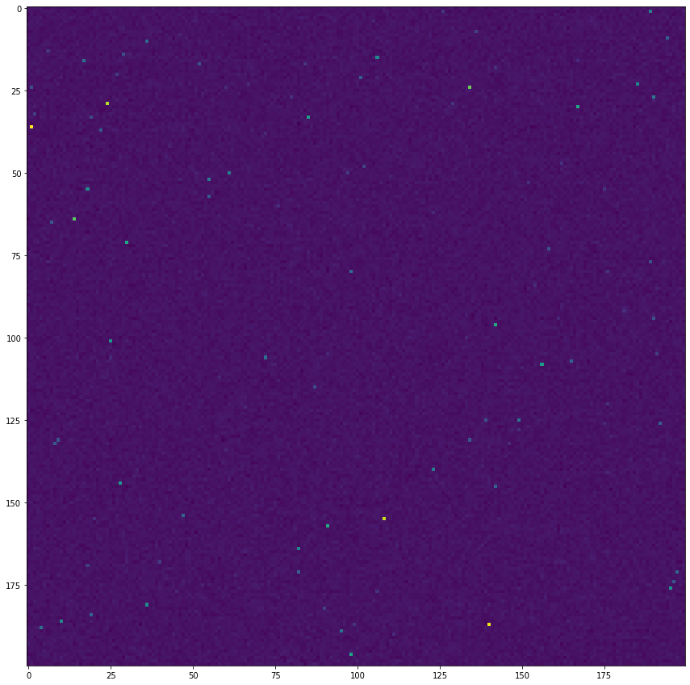

```
(200, 200)
```

```python
fig, ax = plt.subplots(1,1)
ax.imshow(imagestack[:,:,1])
plt.show()
imagestack[:,:,1].shape
```

```python
fig, ax = plt.subplots(1,1)
ax.hist(image1,bins=200)
plt.show()
```

[output not shown]

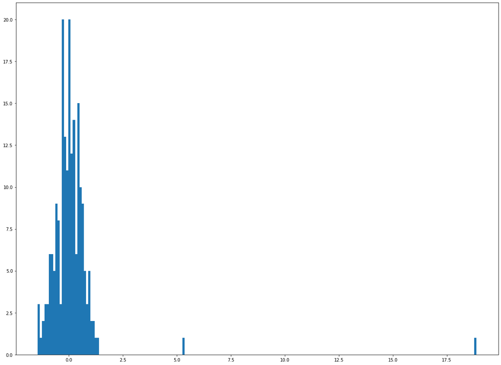

```python
fig, ax = plt.subplots(1,1)
ax.hist(image1[1], bins=200)
plt.show()
```

Based on exploring a few images in the image stack, the picture appears to be spatially consistent. The above histogram shows that the background signal is distributed normally, with a few "signal" spikes of interest that appear at a greater signal level than the background signal. This indicates no signal contamination.

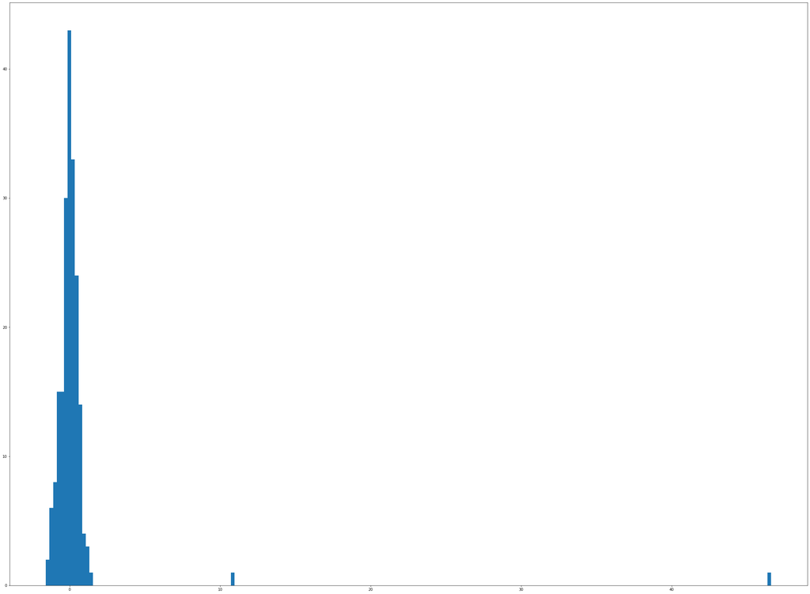

```python
fig, ax = plt.subplots(1,1)
ax.hist(imagestack[:,1,5], bins=200)
plt.show()
```

Comparing the 2 histograms, the signal spikes appear at different signal levels (on the x axis). However, the background still has a mean of 0 that appears normally distributed. So I would conclude that the background is not time dependent.

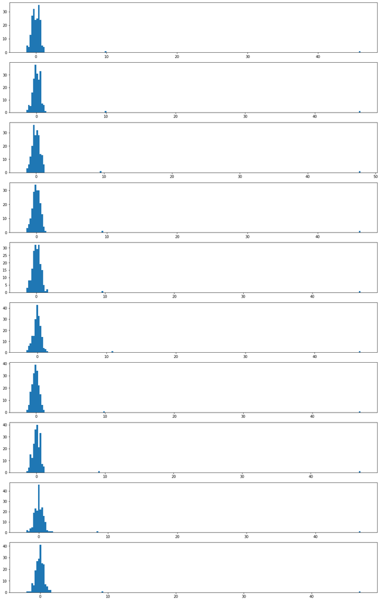

```python
fig, ax = plt.subplots(10, 1)
for i in range(10):
    ax[i].hist(imagestack[:,1,i], bins=200)

fig = matplotlib.pyplot.gcf()
fig.set_size_inches(18.5, 30.5)
plt.show()
```

There doesn't appear to be any transient signals. We see the background signal and 2 spikes which occur in all 10 images.